# Drivers of Cost of Care - Exploratory Data Analysis

The dataset is imported into my local postgres SQL database in it's original form. I used SQL to do most of the data cleaning and created some new variables. You may refer to sql.sql for the code.

**New Variables**

- Length of Stay (los)
- Age at admission (age_at_adm)
- Age categorised in bins (age_grp)
- BMI
- BMI Risk
- Total number of medical history (no_med_hist)
- Total number of symptoms (no_sym)
- Total number of pre-op medications (no_meds)
- Total Bill (tot_bill)

**Data Clean-up**

- Converted categorical features into numerical codes
- Standardised the data type
- Impute null values

Total number of data = 3,400 (per row per admission)

```python
# import packages

import psycopg2
import pandas as pd
import numpy as np

# stats
from scipy import stats
import statsmodels.api as sm
import statsmodels.formula.api as smf
import statsmodels.stats.multicomp as multi
from sklearn.feature_selection import chi2
import statsmodels.regression.linear_model as lm

# visualisation
import seaborn as sns
import matplotlib.pyplot as plt

# Processing
from statsmodels.stats.outliers_influence import variance_inflation_factor
from sklearn.model_selection import train_test_split

# Modeling
from sklearn.tree import DecisionTreeRegressor
from sklearn.linear_model import LinearRegression
from sklearn import linear_model
from sklearn import tree


%config InlineBackend.figure_format = 'retina'
%matplotlib inline

# display options

pd.set_option('display.max_columns', 200)
pd.set_option('display.max_rows',200)
pd.set_option('display.max_colwidth',200)
```

```python
# connect to database

engine = psycopg2.connect("dbname=holmusk user=joannasyeow")
f = open("sql.sql", "r")
sql = f.read()
df = pd.read_sql(sql, con=engine)
```

```python
# have a quick look at our data

df.head()
```

|  | id_ | patient_id | gender_c | resident_status_c | race_c | age_at_adm | age_grp | los | mth_adm | qrt_adm | yr_adm | medical_history_1 | medical_history_2_c | medical_history_3_c | medical_history_4 | medical_history_5_c | medical_history_6 | medical_history_7 | no_med_hist | preop_medication_1 | preop_medication_2 | preop_medication_3 | preop_medication_4 | preop_medication_5 | preop_medication_6 | no_meds | symptom_1 | symptom_2 | symptom_3 | … |
| --- | --- | --- | --- | --- | --- | --- | --- | --- | --- | --- | --- | --- | --- | --- | --- | --- | --- | --- | --- | --- | --- | --- | --- | --- | --- | --- | --- | --- | --- | --- |
| 0 | 8461069832 | 00225710a878eff524a1d13be817e8e2 | 1 | 0 | 2 | 31 | 0 | 12 | 4.0 | 2.0 | 2014.0 | 0 | 0 | 0 | 0 | 0 | 0 | 1 | 1 | 0 | 0 | 0 | 1 | 0 | 0 | 1 | 0 | 0 | 1 | … |
| 1 | 5621737529 | 0029d90eb654699c18001c17efb0f129 | 1 | 0 | 2 | 69 | 1 | 13 | 11.0 | 4.0 | 2012.0 | 0 | 1 | 0 | 0 | 0 | 1 | 0 | 2 | 0 | 0 | 0 | 0 | 1 | 0 | 1 | 0 | 1 | 0 | … |
| 2 | 9921582850 | 0040333abd68527ecb53e1db9073f52e | 0 | 0 | 1 | 41 | 0 | 12 | 1.0 | 1.0 | 2013.0 | 0 | 1 | 0 | 0 | 0 | 0 | 1 | 2 | 0 | 0 | 1 | 1 | 1 | 0 | 3 | 0 | 1 | 0 | … |
| 3 | 7239419545 | 00473b58e3dc8ae37b3cb34069705083 | 1 | 0 | 2 | 38 | 0 | 5 | 2.0 | 1.0 | 2014.0 | 1 | 0 | 0 | 0 | 0 | 0 | 0 | 1 | 0 | 0 | 1 | 1 | 1 | 0 | 3 | 0 | 1 | 1 | … |
| 4 | 9476531069 | 0078662d1d983dde68ea057c42d5b5cf | 0 | 2 | 3 | 70 | 1 | 12 | 4.0 | 2.0 | 2012.0 | 0 | 1 | 0 | 0 | 0 | 1 | 0 | 2 | 1 | 0 | 1 | 1 | 1 | 0 | 4 | 0 | 1 | 0 | … |

```python
df.describe()
```

|  | id_ | gender_c | resident_status_c | race_c | age_at_adm | age_grp | los | mth_adm | qrt_adm | yr_adm | medical_history_1 | medical_history_2_c | medical_history_3_c | medical_history_4 | medical_history_5_c | medical_history_6 | medical_history_7 | no_med_hist | preop_medication_1 | preop_medication_2 | preop_medication_3 | preop_medication_4 | preop_medication_5 | preop_medication_6 | no_meds | symptom_1 | symptom_2 | symptom_3 | symptom_4 | … |
| --- | --- | --- | --- | --- | --- | --- | --- | --- | --- | --- | --- | --- | --- | --- | --- | --- | --- | --- | --- | --- | --- | --- | --- | --- | --- | --- | --- | --- | --- | --- |
| count | 3.400000e+03 | 3400.000000 | 3400.000000 | 3400.000000 | 3400.000000 | 3400.000000 | 3400.000000 | 3400.000000 | 3400.000000 | 3400.000000 | 3400.000000 | 3400.000000 | 3400.000000 | 3400.000000 | 3400.000000 | 3400.000000 | 3400.000000 | 3400.000000 | 3400.000000 | 3400.000000 | 3400.000000 | 3400.000000 | 3400.000000 | 3400.000000 | 3400.000000 | 3400.000000 | 3400.000000 | 3400.000000 | 3400.000000 | … |
| mean | 8.004280e+09 | 0.500588 | 0.246176 | 2.214412 | 52.542647 | 0.416471 | 11.051176 | 6.484412 | 2.502353 | 2013.009706 | 0.169118 | 0.290000 | 0.136176 | 0.052059 | 0.058235 | 0.254706 | 0.254412 | 1.214706 | 0.503824 | 0.591176 | 0.820882 | 0.523235 | 0.819706 | 0.744118 | 4.002941 | 0.619706 | 0.662353 | 0.544706 | 0.726471 | … |
| std | 1.610701e+09 | 0.500073 | 0.529492 | 0.691795 | 14.681475 | 0.493046 | 2.850140 | 3.414452 | 1.115298 | 1.422167 | 0.374911 | 0.453829 | 0.343026 | 0.222178 | 0.234222 | 0.435760 | 0.435594 | 0.971992 | 0.500059 | 0.491689 | 0.383507 | 0.499533 | 0.384489 | 0.436420 | 1.106823 | 0.485530 | 0.472977 | 0.498071 | 0.445836 | … |
| min | 1.350319e+09 | 0.000000 | 0.000000 | 1.000000 | 22.000000 | 0.000000 | 1.000000 | 1.000000 | 1.000000 | 2011.000000 | 0.000000 | 0.000000 | 0.000000 | 0.000000 | 0.000000 | 0.000000 | 0.000000 | 0.000000 | 0.000000 | 0.000000 | 0.000000 | 0.000000 | 0.000000 | 0.000000 | 0.000000 | 0.000000 | 0.000000 | 0.000000 | 0.000000 | … |
| 25% | 7.094585e+09 | 0.000000 | 0.000000 | 2.000000 | 40.000000 | 0.000000 | 9.000000 | 4.000000 | 2.000000 | 2012.000000 | 0.000000 | 0.000000 | 0.000000 | 0.000000 | 0.000000 | 0.000000 | 0.000000 | 0.000000 | 0.000000 | 0.000000 | 1.000000 | 0.000000 | 1.000000 | 0.000000 | 3.000000 | 0.000000 | 0.000000 | 0.000000 | 0.000000 | … |
| 50% | 8.370572e+09 | 1.000000 | 0.000000 | 2.000000 | 51.000000 | 0.000000 | 11.000000 | 6.000000 | 2.000000 | 2013.000000 | 0.000000 | 0.000000 | 0.000000 | 0.000000 | 0.000000 | 0.000000 | 0.000000 | 1.000000 | 1.000000 | 1.000000 | 1.000000 | 1.000000 | 1.000000 | 1.000000 | 4.000000 | 1.000000 | 1.000000 | 1.000000 | 1.000000 | … |
| 75% | 9.293090e+09 | 1.000000 | 0.000000 | 3.000000 | 65.000000 | 1.000000 | 13.000000 | 10.000000 | 4.000000 | 2014.000000 | 0.000000 | 1.000000 | 0.000000 | 0.000000 | 0.000000 | 1.000000 | 1.000000 | 2.000000 | 1.000000 | 1.000000 | 1.000000 | 1.000000 | 1.000000 | 1.000000 | 5.000000 | 1.000000 | 1.000000 | 1.000000 | 1.000000 | … |
| max | 9.999633e+09 | 1.000000 | 2.000000 | 4.000000 | 85.000000 | 1.000000 | 20.000000 | 12.000000 | 4.000000 | 2015.000000 | 1.000000 | 1.000000 | 1.000000 | 1.000000 | 1.000000 | 1.000000 | 1.000000 | 5.000000 | 1.000000 | 1.000000 | 1.000000 | 1.000000 | 1.000000 | 1.000000 | 6.000000 | 1.000000 | 1.000000 | 1.000000 | 1.000000 | … |

```python
df.info()
```

```
<class 'pandas.core.frame.DataFrame'>
RangeIndex: 3400 entries, 0 to 3399
Data columns (total 40 columns):
id_                    3400 non-null int64
patient_id             3400 non-null object
gender_c               3400 non-null int64
resident_status_c      3400 non-null int64
race_c                 3400 non-null int64
age_at_adm             3400 non-null int64
age_grp                3400 non-null int64
los                    3400 non-null int64
mth_adm                3400 non-null float64
qrt_adm                3400 non-null float64
yr_adm                 3400 non-null float64
medical_history_1      3400 non-null int64
medical_history_2_c    3400 non-null int64
medical_history_3_c    3400 non-null int64
medical_history_4      3400 non-null int64
medical_history_5_c    3400 non-null int64
medical_history_6      3400 non-null int64
medical_history_7      3400 non-null int64
no_med_hist            3400 non-null int64
preop_medication_1     3400 non-null int64
preop_medication_2     3400 non-null int64
preop_medication_3     3400 non-null int64
preop_medication_4     3400 non-null int64
preop_medication_5     3400 non-null int64
preop_medication_6     3400 non-null int64
no_meds                3400 non-null int64
symptom_1              3400 non-null int64
symptom_2              3400 non-null int64
symptom_3              3400 non-null int64
symptom_4              3400 non-null int64
symptom_5              3400 non-null int64
no_sym                 3400 non-null int64
lab_result_1           3400 non-null float64
lab_result_2           3400 non-null float64
lab_result_3           3400 non-null float64
weight                 3400 non-null float64
height                 3400 non-null float64
bmi                    3400 non-null float64
bmi_risk_c             3400 non-null int64
tot_bill               3400 non-null float64
dtypes: float64(10), int64(29), object(1)
memory usage: 1.0+ MB
```

```python
# check for duplicated rows

len(df.loc[df.duplicated(), :])
```

```
0
```

**How many unique patients do we have ?**

```python
df['patient_id'].nunique()
```

```
3000
```

Great ! Seems like data is all cleaned up from SQL end.

## Variable Analysis

In this part of the workbook, i'll be using some visualisation and statstical models to look into our data

**Length of Stay**

```
R:  0.009005747664634453
P-value:  0.5996260372387328
```

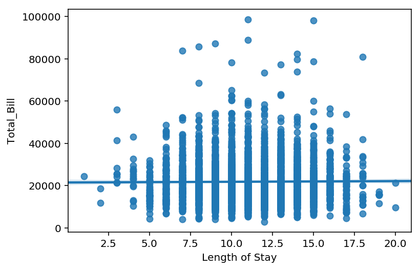

```python
# Pearson Corrleation Coefficient on number of medical history
print ('R: ',stats.pearsonr(df['los'], df['tot_bill'])[0])
print ('P-value: ',stats.pearsonr(df['los'], df['tot_bill'])[1])

b = sns.regplot(df['los'],df['tot_bill'])
b.set_xlabel("Length of Stay",fontsize=10)
b.set_ylabel("Total_Bill",fontsize=10)
plt.show()
```

The first thing that came to my mind for the variable length of stay, is the effect of ward costs to the total bill. I thought it makes logical sense that the total bill will increase with longer stay in the hospital. However, I did a correlation coefficient analysis on los to the total bill and it proved my theory wrong. I will not be using this variable, and will use the total bill as a target variable.

**Year of Admission**

```
R:  0.01919453563957382
P-value:  0.26317611949047154
```

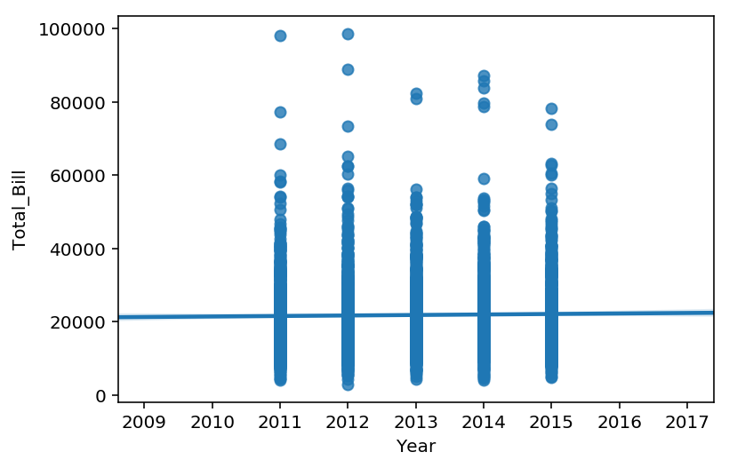

```python
# Pearson Corrleation Coefficient on Year of Admission
print ('R: ',stats.pearsonr(df['yr_adm'], df['tot_bill'])[0])
print ('P-value: ',stats.pearsonr(df['yr_adm'], df['tot_bill'])[1])

b = sns.regplot(df['yr_adm'],df['tot_bill'])
b.set_xlabel("Year",fontsize=10)
b.set_ylabel("Total_Bill",fontsize=10)
plt.show()
```

This is to see if total bill increases over the years

# Target Variable

The distribution of the data is highly skewed to the right. A natural log is applied to the data to ensure approximate normality.

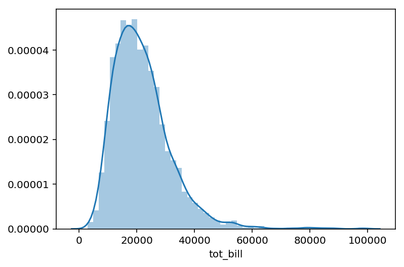

```
p-value (Sharpiro-Wilk Test):  7.132609183413319e-43
```

```python
# Sharpiro-Wilk Test for Normality

sns.distplot(df['tot_bill'])
plt.show()
print ('p-value (Sharpiro-Wilk Test): ',stats.shapiro(df['tot_bill'])[1])
```

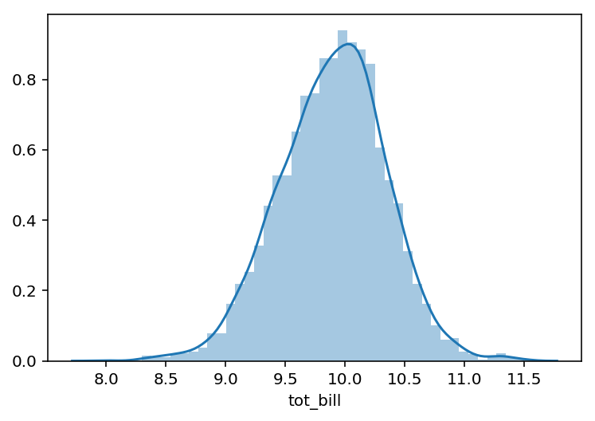

```
p-value (Sharpiro-Wilk Test):  2.660954805833171e-06
```

```python
# Sharpiro-Wilk Test for Normality

sns.distplot(np.log(df['tot_bill']))
plt.show()
print ('p-value (Sharpiro-Wilk Test): ',stats.shapiro(np.log(df['tot_bill']))[1])
```

Now that looks better !

```python
# create new target variable
df['log_bill'] = np.log(df['tot_bill'])
```

# Demographics Analysis

**Gender, Resident Status, Race, Age**

A deep dive to have a look at the distribution of our demographics data and how it impacts the cost of care

```python
# demographics analysis

demo_col = ['gender_c','resident_status_c','race_c','age_grp']
```

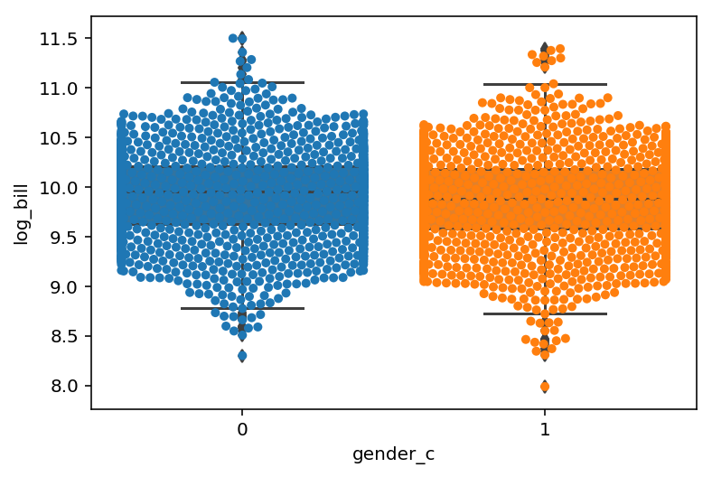

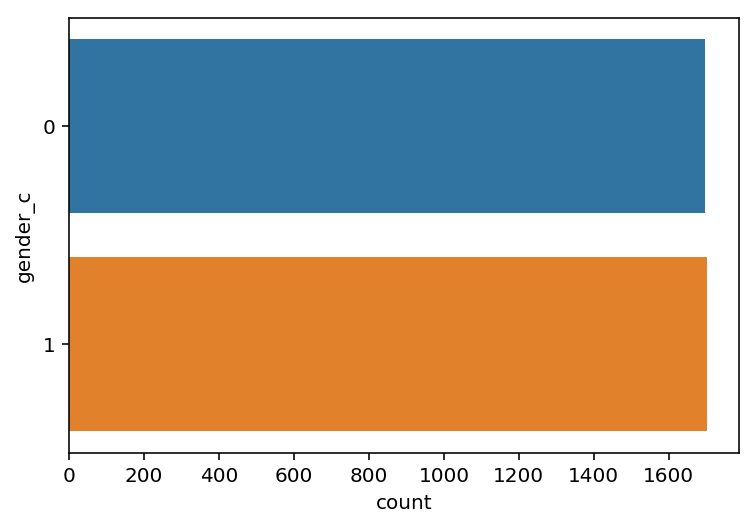

```
Value Count:
gender_c
0    1503
1    1497
Name: patient_id, dtype: int64

Mean Total Bills:
gender_c
0    22446.032656
1    21273.489318
Name: tot_bill, dtype: float64
```

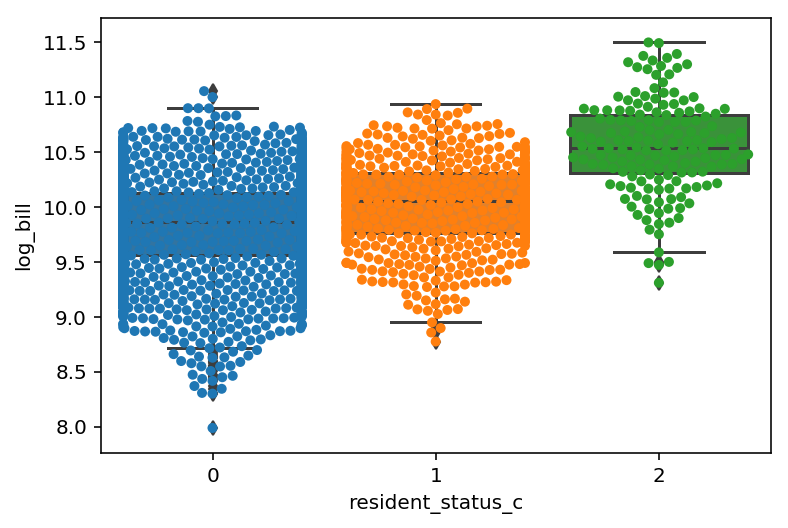

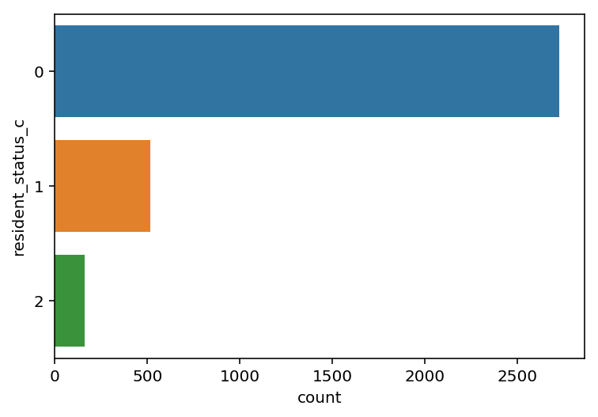

```
Value Count:
resident_status_c
0    2392
1     465
2     143
Name: patient_id, dtype: int64

Mean Total Bills:
resident_status_c
0    20211.437074
1    24370.057942
2    41703.775404
Name: tot_bill, dtype: float64
```

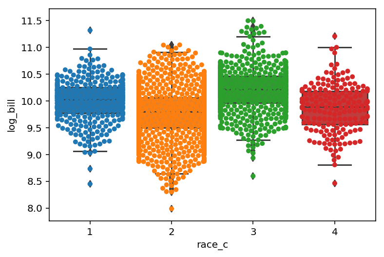

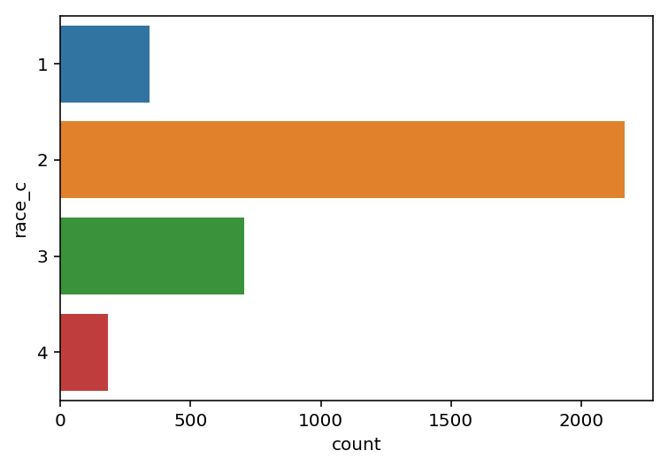

```
Value Count:
race_c
1     295
2    1915
3     629
4     161
Name: patient_id, dtype: int64

Mean Total Bills:
race_c
1    23682.724680
2    19118.897909
3    29506.016223
4    21320.757596
Name: tot_bill, dtype: float64
```

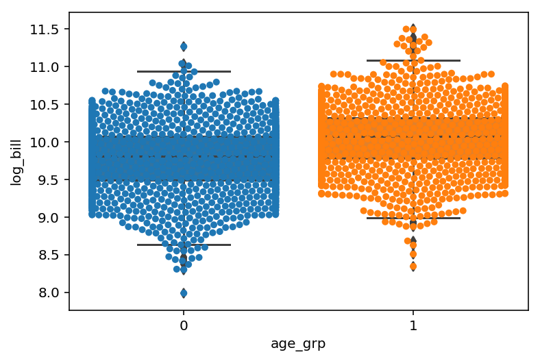

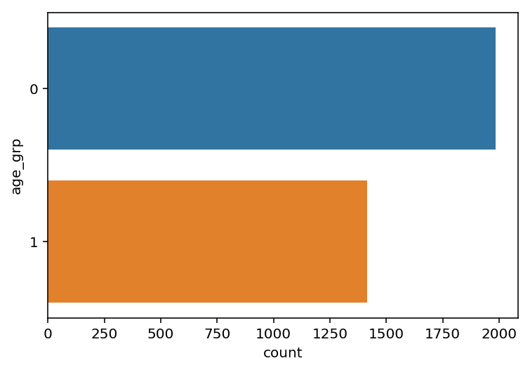

```
Value Count:
age_grp
0    1755
1    1252
Name: patient_id, dtype: int64

Mean Total Bills:
age_grp
0    19333.586184
1    25397.604011
Name: tot_bill, dtype: float64
```

```python
# descriptive analysis for demographics data

for c in demo_col:
        sns.boxplot(y=df['log_bill'],x=df[c])
        sns.swarmplot(y=df['log_bill'],x=df[c])
        plt.show()
        sns.countplot(y = df[c])
        plt.show()
        print()
        print('Value Count:')
        print(df.groupby(c)['patient_id'].nunique())
        print()
        print('Mean Total Bills:')
        print(df.groupby(c)['tot_bill'].mean())
        print()
#         print('Mean Average Bills:')
#         print (df.groupby(c)['avg_bill'].mean())
#         print()
```

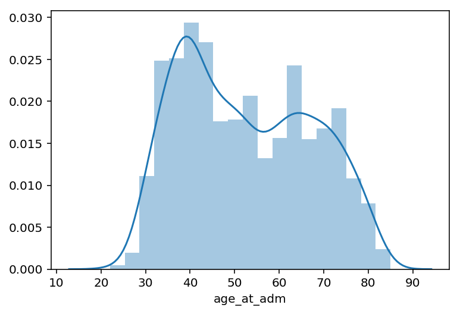

```python
# distribution plot for age of admission

sns.distplot(df['age_at_adm'])
plt.show()
print()
```

### One-way ANOVA

on demographics variables

```python
# gender

# stats f_oneway function
fvalue, pvalue = stats.f_oneway(df[df['gender_c'] == 1]['log_bill'], df[df['gender_c'] == 0]['log_bill'])
print('F:',fvalue)
print('P-value: ',pvalue)
if pvalue < 0.01 :
    print('Since pvalue is < 0.01, we reject the null hypothesis that two or more groups have the same population mean at 0.01 significance level.')
    print('Hypothesis: Pass')
else:
    print('Since pvalue is > 0.01, we are unable to reject the null hypothesis at 0.01 significance level. We conclude that there is insufficient evidence to claim that two or more groups do not have the same population mean.')
```

```
F: 14.688061233548426
P-value:  0.00012914299884498676
Since pvalue is < 0.01, we reject the null hypothesis that two or more groups have the same population mean at 0.01 significance level.
Hypothesis: Pass
```

```python
# resident status

# stats f_oneway function
fvalue, pvalue = stats.f_oneway(df[df['resident_status_c'] == 2]['log_bill'],df[df['resident_status_c'] == 1]['log_bill'], df[df['resident_status_c'] == 0]['log_bill'])
print('F:',fvalue)
print('P-value: ',pvalue)
if pvalue < 0.01 :
    print('Since pvalue is < 0.01, we reject the null hypothesis that two or more groups have the same population mean at 0.01 significance level.')
    print('Hypothesis: Pass')
else:
    print('Since pvalue is > 0.01, we are unable to reject the null hypothesis at 0.01 significance level. We conclude that there is insufficient evidence to claim that two or more groups do not have the same population mean.')
```

```
F: 256.0352539490124
P-value:  2.6849736789927643e-104
Since pvalue is < 0.01, we reject the null hypothesis that two or more groups have the same population mean at 0.01 significance level.
Hypothesis: Pass
```

```python
# race status

# stats f_oneway function
fvalue, pvalue = stats.f_oneway(df[df['race_c'] == 3]['log_bill'],df[df['race_c'] == 2]['log_bill'],df[df['race_c'] == 1]['log_bill'], df[df['race_c'] == 4]['log_bill'])
print('F:',fvalue)
print('P-value: ',pvalue)
if pvalue < 0.01 :
    print('Since pvalue is < 0.01, we reject the null hypothesis that two or more groups have the same population mean at 0.01 significance level.')
    print('Hypothesis: Pass')
else:
    print('Since pvalue is > 0.01, we are unable to reject the null hypothesis at 0.01 significance level. We conclude that there is insufficient evidence to claim that two or more groups do not have the same population mean.')
```

```
F: 212.96147625392828
P-value:  1.4122420594386528e-126
Since pvalue is < 0.01, we reject the null hypothesis that two or more groups have the same population mean at 0.01 significance level.
Hypothesis: Pass
```

### Tukey's Honestly Significant Difference

on race

```
Multiple Comparison of Means - Tukey HSD, FWER=0.05
====================================================
group1 group2 meandiff p-adj   lower   upper  reject
----------------------------------------------------
     1      2  -0.2285  0.001 -0.2896 -0.1673   True
     1      3   0.2108  0.001  0.1415  0.2801   True
     1      4  -0.1343  0.002 -0.2308 -0.0379   True
     2      3   0.4393  0.001  0.3936  0.4849   True
     2      4   0.0941 0.0153   0.013  0.1753   True
     3      4  -0.3451  0.001 -0.4325 -0.2577   True
----------------------------------------------------
```

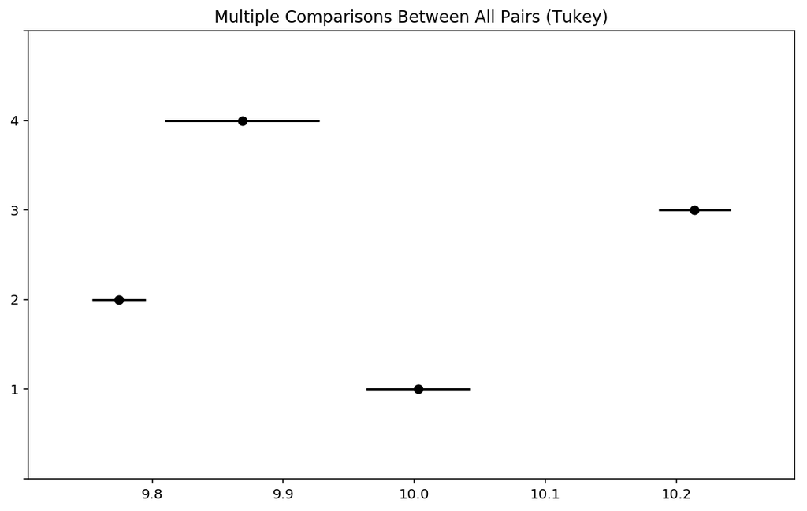

```python
def tukey_hsd(df,col,aspect='log_bill'):

    # DataFrame.
    tukeyhsd = multi.pairwise_tukeyhsd(df[aspect].values,df[col].values, alpha=0.05)
    result = tukeyhsd.summary()
    print(result)

    #visualisation
    tukeyhsd.plot_simultaneous(figsize=(10,6))

tukey_hsd(df,'race_c')
```

```python
# age group

# stats f_oneway function
fvalue, pvalue = stats.f_oneway(df[df['age_grp'] == 0]['log_bill'],df[df['age_grp'] == 1]['log_bill'])
print('F:',fvalue)
print('P-value: ',pvalue)
if pvalue < 0.01 :
    print('Since pvalue is < 0.01, we reject the null hypothesis that two or more groups have the same population mean at 0.01 significance level.')
    print('Hypothesis: Pass')
else:
    print('Since pvalue is > 0.01, we are unable to reject the null hypothesis at 0.01 significance level. We conclude that there is insufficient evidence to claim that two or more groups do not have the same population mean.')
```

```
F: 327.881539662501
P-value:  4.9329661609778044e-70
Since pvalue is < 0.01, we reject the null hypothesis that two or more groups have the same population mean at 0.01 significance level.
Hypothesis: Pass
```

# Resident Status

Resident status can be easily explained by having different subsidy amounts. Based on MOH website, Singaporeans enjoy subsidies between 50% - 85% and PR enjoy subsidies between 25% to 55%.

The subsidy and cost is also affected by the choice of ward class. Due to the lack of data, unable to modify the total bills to analyse the base cost before subsidies.

# Quick Look

### Pearson Correlation Coefficient

on Continous Variables

```python
# define continous variables and binary variables

con_col = ['los','yr_adm','age_at_adm','no_med_hist','no_meds','no_sym','bmi','lab_result_1','lab_result_2','lab_result_3']
bin_col = ['gender_c','resident_status_c','race_c','medical_history_1','medical_history_2_c','medical_history_3_c','medical_history_4','medical_history_5_c','medical_history_6','medical_history_7','preop_medication_1','preop_medication_2','preop_medication_3','preop_medication_4','preop_medication_5','preop_medication_6','symptom_1','symptom_2','symptom_3','symptom_4','symptom_5']
target = ['log_bill']
```

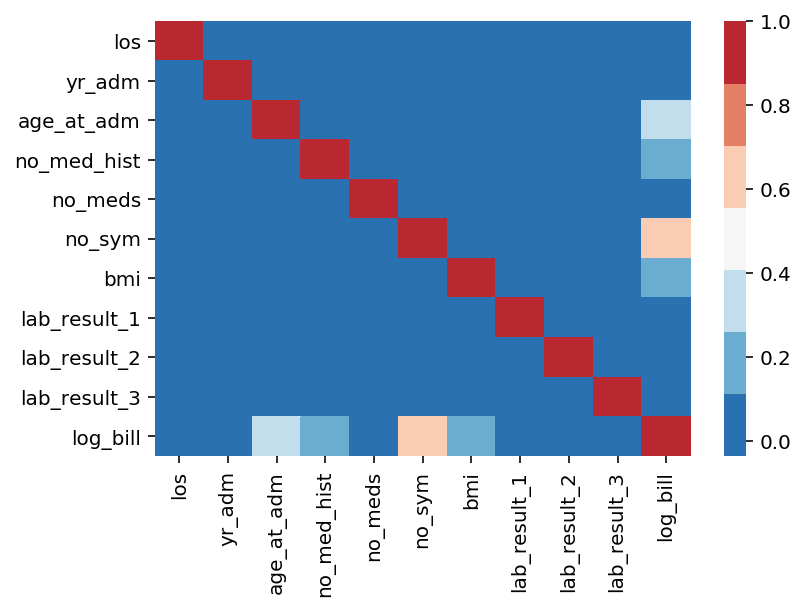

```python
# a quick summary of our continuous variables

# sns.set(rc={"figure.figsize": (15, 10)})

corr = df[con_col+target].corr()
cmap = sns.color_palette("RdBu_r", 7)

sns.heatmap(corr,cmap=cmap)
```

The lighter blue areas shows some evidence that there seems to be some variables with small positive correlation to the total bill.

**bmi** : To a certain extent, it is logical that the higher the bmi, the higher the total bill due to higher health risk. However, a low bmi may have a risk of nutritional deficiency that may lead to more complications. We will examine a similar variable - bmi_risk later on.

**no_med_hist**/**no_sym** : The more medical history and symptoms, the more medication, procedures will be required.

**age at adm** : Geriatric patients tend to have more co-morbidities, complications, more medication, procedures thus requiring more medical attention.

**length of stay** is definitely unusual. Will not be using this variable.

### Decision Tree

a quick dirty look into feature importances for each variable

```
R2 Score:  0.9999999957011912
```

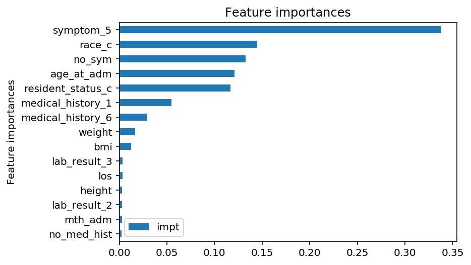

```python
y = df['log_bill']
x = df.drop(['id_','tot_bill','id_','patient_id','age_grp','log_bill'],axis=1)
tree = DecisionTreeRegressor(random_state=222)
tree.fit(x,y)

print ('R2 Score: ', tree.score(x,y) )

impt = pd.DataFrame(index=x.columns)
impt['impt'] = tree.feature_importances_
impt = impt.sort_values('impt').tail(15)

# sns.set(rc={"figure.figsize": (15, 10)})
fig, ax = plt.subplots()
impt.plot.barh(ax=ax)
ax.set_title("Feature importances")
ax.set_ylabel("Feature importances")
plt.show()
```

### CHI 2 Test on Categorical Features

```
                     gender_c  resident_status_c    race_c  medical_history_1  \
gender_c             0.000000           0.439294  0.294237           0.511123
resident_status_c    0.052976           0.000000  0.424662           0.886243
race_c               0.563346           0.972732  0.000000           0.607364
medical_history_1    0.396688           0.803551  0.752101           0.000000
medical_history_2_c  0.682606           0.651335  0.822192           0.848406
medical_history_3_c  0.725864           0.094554  0.390328           0.682312
medical_history_4    0.266216           0.559530  0.277319           0.430232
medical_history_5_c  0.091209           0.302843  0.576006           0.778259
medical_history_6    0.027145           0.415206  0.954716           0.754066
medical_history_7    0.048671           0.140656  0.691951           0.876508
preop_medication_1   0.753727           0.523441  0.909985           0.964088
preop_medication_2   0.727281           0.555995  0.597701           0.996509
preop_medication_3   0.729280           0.689969  0.891039           0.919852
preop_medication_4   0.135841           0.643858  0.717662           0.906337
preop_medication_5   0.474903           0.872689  0.989245           0.973027
preop_medication_6   0.765895           0.701365  0.993646           0.430387
symptom_1            0.769031           0.730893  0.858340           0.712924
symptom_2            0.564382           0.863515  0.851965           0.146135
symptom_3            0.208047           0.601860  0.542501           0.270009
symptom_4            0.507905           0.929567  0.959367           0.718294
symptom_5            0.585062           0.938830  0.445003           0.575227

                     medical_history_2_c  medical_history_3_c  \
gender_c                        0.731638             0.789773
resident_status_c               0.555977             0.069987
race_c                          0.910819             0.873787
medical_history_1               0.836177             0.688103
medical_history_2_c             0.000000             0.366280
medical_history_3_c             0.318988             0.000000
medical_history_4               0.015097             0.981950
medical_history_5_c             0.804556             0.539254
medical_history_6               0.772529             0.432118
medical_history_7               0.265824             0.474916
preop_medication_1              0.196992             0.817797
preop_medication_2              0.727085             0.503565
preop_medication_3              0.789809             0.702058
preop_medication_4              0.790277             0.930705
preop_medication_5              0.700011             0.637810
preop_medication_6              0.448463             0.368113
```

[output cut: 128 more lines]

```
medical_history_4     0.147721   0.736251
medical_history_5_c   0.507318   0.503450
medical_history_6     0.440278   0.313083
medical_history_7     0.669115   0.511012
preop_medication_1    0.201687   0.420342
preop_medication_2    0.446743   0.497026
preop_medication_3    0.985751   0.993941
preop_medication_4    0.082856   0.597653
preop_medication_5    0.542671   0.646375
preop_medication_6    0.753895   0.711581
symptom_1             0.684061   0.627940
symptom_2             0.636016   0.923536
symptom_3             0.242449   0.627321
symptom_4             0.000000   0.660724
symptom_5             0.563724   0.000000
```

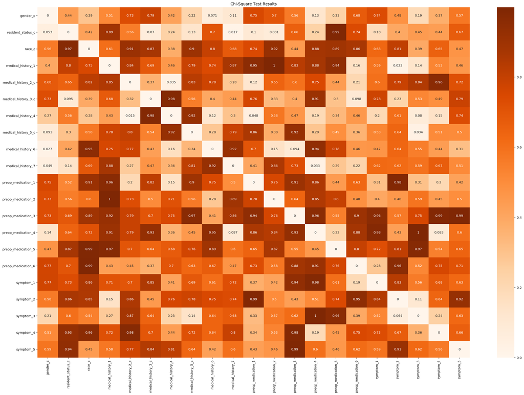

```python
# CHI 2 Test

A = df[bin_col]
resultant = pd.DataFrame(data=[(0 for i in range(len(A.columns))) for i in range(len(A.columns))],
                         columns=list(A.columns))
resultant.set_index(pd.Index(list(A.columns)), inplace = True)

# Finding p_value for all columns and putting them in the resultant matrix
for i in list(A.columns):
    for j in list(A.columns):
        if i != j:
            chi2_val, p_val = chi2(np.array(A[i]).reshape(-1, 1), np.array(A[j]).reshape(-1, 1))
            resultant.loc[i,j] = p_val
print(resultant)

# Plotting a heatmap
fig = plt.figure(figsize=(30,20))
sns.heatmap(resultant, annot=True, cmap='Oranges')
plt.title('Chi-Square Test Results')
plt.show()
```